# Tugas Inferensi

6181801015 - Gian Martin D.; 6181801044 - Yalvi Hidayat; 6181801077 - Bernadus Lukas

## Data

General Social Survey (GSS) adalah data yang diperoleh dari survey pada orang dewasa di Amerika Serikat sejak tahun 1972. Data diperoleh dari masyarakat kontemporer Amerika guna memonitor dan menjelaskan perubahan tren pada opini, sikap, dan perilaku masyarakat. Karena data diambil secara acak dari populasi, maka dapat dilakukan inferensi namun tidak dapat untuk menyatakan causation(sebab-akibat)

```r
library(dplyr)
library(tidyverse)
```

```r
library(ggplot2)

data <- load("gss.Rdata")
data <- data.frame(gss)
```

**Pertanyaan 1** Apakah ada perbedaan proporsi untuk dua status pernikahan (`marital`) (Married dan Divorced) berdasarkan dua kelompok jenis pekerjaan (`wrkstat`) (Fulltime dan Parttime) H0: Tidak ada perbedaan proporsi. Ha: Terdapat perbedaan proporsi. Alasan: kami ingin mengetahui apakah status pernikahan mempengaruhi status pekerjaan seseorang. Karena ada anggapan dimana seseorang yang sudah bercerai akan lebih giat bekerja entah untuk memenuhi kebutuhan sehari-harinya ataupun hanya untuk mengisi waktu senggang.

##### Filter dataset berdasarkan `wrkstat` untuk “Working Fulltime” dan “Working Parttime”, dan `marital` untuk “Married” dan “Divorced”, lalu kelompokkan

```r
marital_wrkstat <- data %>%
  filter((marital == "Married" | marital == "Divorced") & (wrkstat == "Working Fulltime" | wrkstat == "Working Parttime")) %>%
  group_by(wrkstat, marital) %>%
  summarise(jumlah = n())
marital_wrkstat <- na.omit(marital_wrkstat)
marital_wrkstat
```

| wrkstat | marital | jumlah |
| --- | --- | --- |
| Working Fulltime | Married | 16027 |
| Working Fulltime | Divorced | 4213 |
| Working Parttime | Married | 3005 |
| Working Parttime | Divorced | 604 |

##### Buat boxplot untuk memvisualisasi

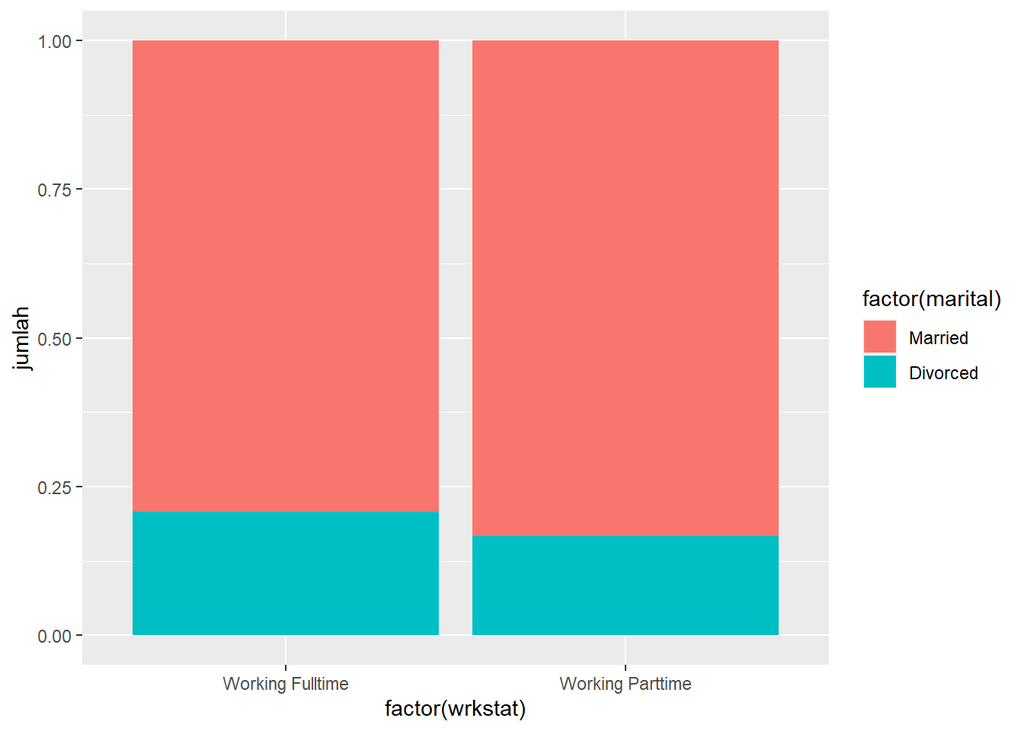

```r
ggplot(marital_wrkstat, aes(x=factor(wrkstat), y=jumlah, fill=factor(marital)))+
  geom_col(position="fill")
```

Dari boxplot yang dibuat, terlihat ada perbedaan dimana proporsi bercerai untuk Fulltime lebih tinggi dibanding Parttime.

##### Lakukan prop test pada hasil pengelompokan

```r
prop.test(c(604, 4213), c(3005, 16027), correct = TRUE)
```

```
##
##  2-sample test for equality of proportions with continuity correction
##
## data:  c(604, 4213) out of c(3005, 16027)
## X-squared = 50.915, df = 1, p-value = 9.644e-13
## alternative hypothesis: two.sided
## 95 percent confidence interval:
##  -0.07793464 -0.04580651
## sample estimates:
##    prop 1    prop 2
## 0.2009983 0.2628689
```

**Pertanyaan 2** Apakah ada hubungan tingkat pendidikan (`degree`) dengan jumlah anak (`childs`) H0: Tidak ada hubungan antara keduanya Ha: Terdapat hubungan antara keduanya

```r
degree_childs <- data %>%
  group_by(degree, childs) %>%
  summarise(jumlah = n())
degree_childs <- na.omit(degree_childs)
degree_childs
```

| degree | childs | jumlah |
| --- | --- | --- |
| Lt High School | 0 | 2181 |
| Lt High School | 1 | 1691 |
| Lt High School | 2 | 2442 |
| Lt High School | 3 | 1964 |
| Lt High School | 4 | 1357 |
| Lt High School | 5 | 822 |
| Lt High School | 6 | 481 |
| Lt High School | 7 | 299 |
| Lt High School | 8 | 549 |
| High School | 0 | 7791 |

[output cut: 35 more lines]

##### Buat bar plot untuk melihat persebaran data

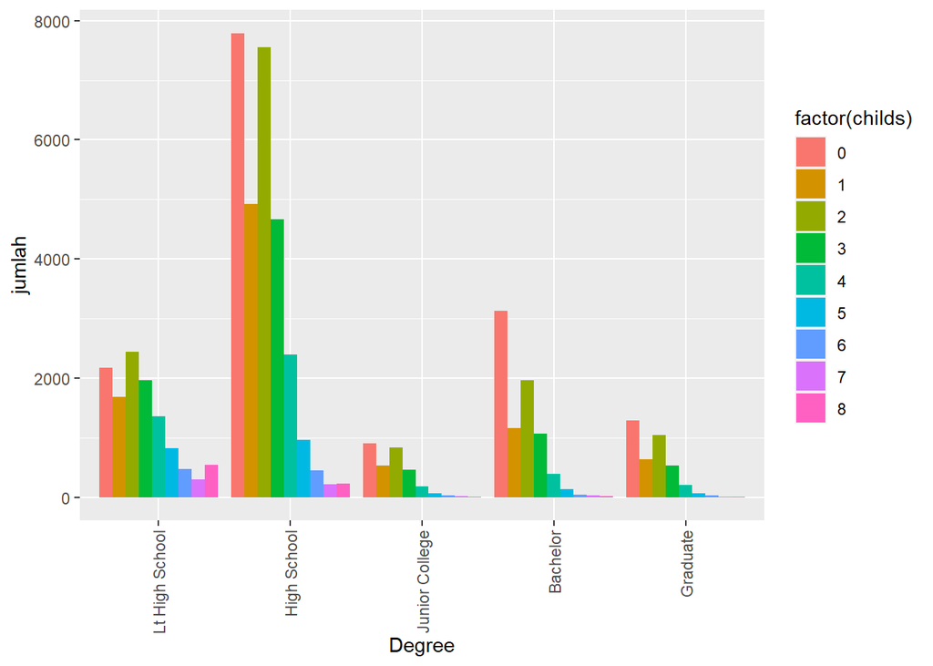

```r
ggplot(degree_childs, aes(x=factor(degree), y=jumlah, fill=factor(childs)))+
  geom_col(position="dodge")+
  theme(axis.text.x = element_text(angle = 90, vjust = 0.5, hjust=1))+
  xlab("Degree")
```

Dari boxplot, terlihat ada sedikit perbedaan dimana tingkat pendidikan yang lebih tinggi cenderung memiliki lebih sedikit anak.

##### Lakukan uji chi squared untuk kolom `degree`dan `childs`

```r
chisq.test(data$degree, data$childs)
```

```
##
##  Pearson's Chi-squared test
##
## data:  data$degree and data$childs
## X-squared = 3619.8, df = 32, p-value < 2.2e-16
```

Dari hasil uji chi square, diperoleh nilai p-value = 2.2e-16. Karena p-value lebih kecil dari 0.05 maka dapat ditolak H0-nya dan menerima Ha.

Alasan: Karena survey ini dilakukan di Amerika,dimana kerap kali kita mendengar berita tentang rasismen.Kelompok kami ingin tahu apakah ras seseorang mempengaruhi penghasilan yang dimiliki atau tidak sama sekali?

##### Kelompokan data berdasarkan `race` dan `income06` dan hitung jumlah masing-masing kelompok

```r
race_income06 <- data %>%
  group_by(race, income06) %>%
  summarise(jumlah = n())
race_income06 <- na.omit(race_income06)
race_income06
```

| race | income06 | jumlah |
| --- | --- | --- |
| White | Under $1 000 | 62 |
| White | $1 000 To 2 999 | 61 |
| White | $3 000 To 3 999 | 47 |
| White | $4 000 To 4 999 | 27 |
| White | $5 000 To 5 999 | 42 |
| White | $6 000 To 6 999 | 64 |
| White | $7 000 To 7 999 | 79 |
| White | $8 000 To 9 999 | 126 |
| White | $10000 To 12499 | 237 |
| White | $12500 To 14999 | 215 |

[output cut: 68 more lines]

##### Buat boxplot untuk visualisasi

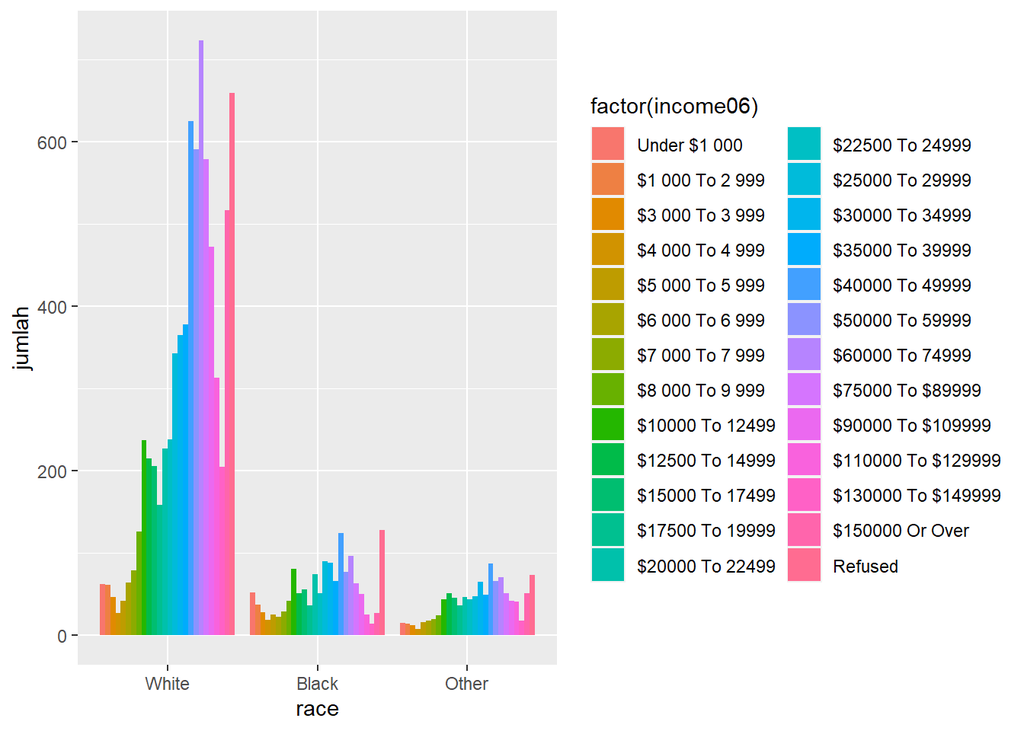

```r
ggplot(race_income06, aes(x=factor(race), y=jumlah, fill=factor(income06)))+
  geom_col(position="dodge")+
  xlab("race")
```

Dari boxplot yang dibuat, dapat terlihat bahwa ras “White” cenderung memiliki pendapatan yang lebih tinggi.

##### Lakukan uji chi squared untuk `race` dan `income06`

```r
chisq.test(data$race, data$income06)
```

```
##
##  Pearson's Chi-squared test
##
## data:  data$race and data$income06
## X-squared = 475.09, df = 50, p-value < 2.2e-16
```